### Unit 2: Climate

### Lesson 4: Examining global atmospheric CO2 trends

#### Skills: Reading .txt files, plotting, saving figures, conditional statements, subsetting

### Explore NASA melting global CO2 data

- Example from http://climate.nasa.gov/vital-signs/carbon-dioxide/
- Raw data from ftp://aftp.cmdl.noaa.gov/products/trends/co2/co2_mm_mlo.txt

Let’s look at global patterns in atmospheric CO2 concentrations by examining the Keeling curve. The Keeling Curve shows seasonal and annual changes in atmospheric carbon dioxide (CO2) concentrations since 1958 at the Mauna Loa Observatory in Hawaii. Mauna Loa is an excellent site for atmospheric data collection due to the elevation and clean air quality. Since this site is in the middle of the Pacific ocean and far from cities, there will be less transient variation due to anthropogenic CO2 emissions. The graph, which was devised by American climate scientist Charles David Keeling of the Scripps Institution of Oceanography, charts the buildup of CO2 in the atmosphere. It is the longest uninterrupted instrumental record of atmospheric CO2 in the world, and it is commonly regarded as one of the best and most recognizable products of a long-term scientific study.

We can read in the CO2 data from NASA at their website. From here you can download a text file and open it to read the metadata at the top. We can also just download the data directly using their ftp:

```r
co2 = read.table("data/co2_mm_mlo.txt", col.names = c("year", "month", "decimal_date", "monthly_average", "deseasonalized", "n_days", "st_dev_days", "monthly_mean_uncertainty"))

# url = 'ftp://aftp.cmdl.noaa.gov/products/trends/co2/co2_mm_mlo.txt'
# co2 = read.table(url, col.names = c("year", "month", "decimal_date", "monthly_average", "deseasonalized", "n_days", "st_dev_days", "monthly_mean_uncertainty"))
```

Now some first-pass data exploration:

```r
class(co2)
## [1] "data.frame"
head(co2)  # prints first 6 rows
##   year month decimal_date monthly_average deseasonalized n_days st_dev_days
## 1 1958     3     1958.203          315.70         314.43     -1       -9.99
## 2 1958     4     1958.288          317.45         315.16     -1       -9.99
## 3 1958     5     1958.370          317.51         314.71     -1       -9.99
## 4 1958     6     1958.455          317.24         315.14     -1       -9.99
## 5 1958     7     1958.537          315.86         315.18     -1       -9.99
## 6 1958     8     1958.622          314.93         316.18     -1       -9.99
##   monthly_mean_uncertainty
## 1                    -0.99
## 2                    -0.99
## 3                    -0.99
## 4                    -0.99
## 5                    -0.99
## 6                    -0.99
summary(co2) # gives type-specific summary stats for each column
##       year          month         decimal_date  monthly_average deseasonalized
##  Min.   :1958   Min.   : 1.000   Min.   :1958   Min.   :312.4   Min.   :314.4
##  1st Qu.:1973   1st Qu.: 4.000   1st Qu.:1974   1st Qu.:329.1   1st Qu.:330.1
##  Median :1989   Median : 6.000   Median :1989   Median :352.9   Median :353.0
##  Mean   :1989   Mean   : 6.495   Mean   :1989   Mean   :355.5   Mean   :355.5
##  3rd Qu.:2005   3rd Qu.: 9.000   3rd Qu.:2005   3rd Qu.:378.8   3rd Qu.:378.6
##  Max.   :2020   Max.   :12.000   Max.   :2021   Max.   :417.1   Max.   :414.9
##      n_days       st_dev_days     monthly_mean_uncertainty
##  Min.   :-1.00   Min.   :-9.990   Min.   :-0.9900
##  1st Qu.:-1.00   1st Qu.:-9.990   1st Qu.:-0.9900
##  Median :25.00   Median : 0.380   Median : 0.1500
##  Mean   :18.61   Mean   :-2.243   Mean   :-0.1187
##  3rd Qu.:28.00   3rd Qu.: 0.550   3rd Qu.: 0.2100
##  Max.   :31.00   Max.   : 1.320   Max.   : 0.5800
```

Where does our time series start and end? What is the maximum CO2 level recorded at Mauna Loa?

```r
range(co2$decimal_date)
## [1] 1958.203 2020.708
max(co2$monthly_average)
## [1] 417.07
```

Let’s plot the monthly average atmospheric CO2 concentration (in ppm) to examine the Keeling curve:

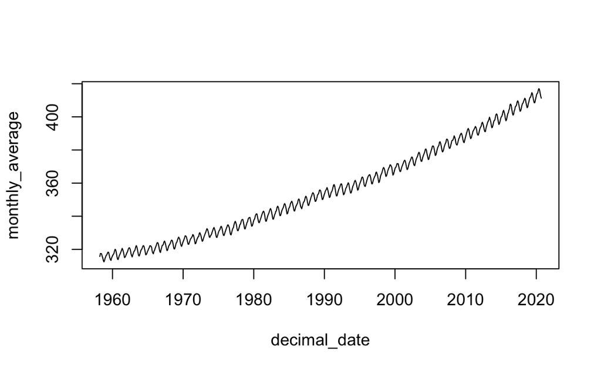

```r
plot(monthly_average ~ decimal_date, type="l", data=co2)
```

NASA was kind enough to inlcude the deseasonalized data. That means they removed the monthly cycle so that we could see the trend over time more easily. Let’s plot the deasonalized data over the monthly average data. We’ll also make our plot prettier by specifying the axes titles and the main figure title.

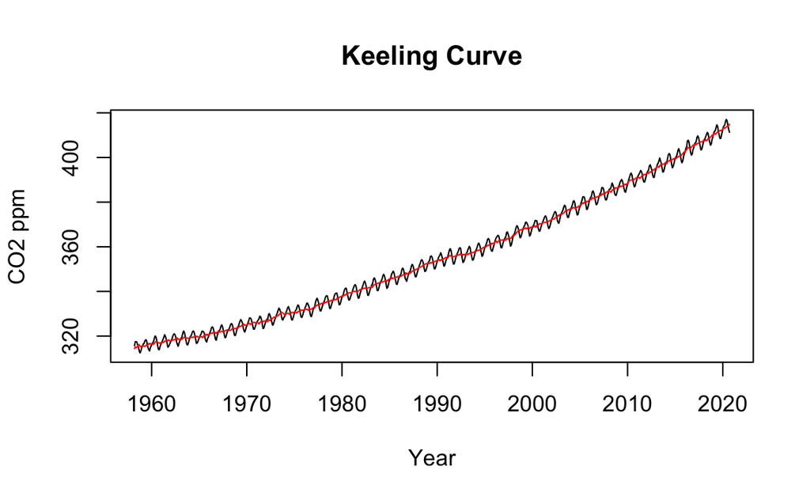

```
## integer(0)
```

```r
#Note '+' keeps lines together so RMarkdown doesn't close the plot before all elements are added
plot(monthly_average ~ decimal_date, type="l", data=co2, ylab="CO2 ppm", xlab="Year", main="Keeling Curve") +
lines(y=co2$deseasonalized, x=co2$decimal_date, col="red")
```

This is pretty great, so let’s save this gorgeous figure and brag about it to all of our friends.

```r
pdf('figures/keelingCurve.pdf', width=7, height=5)
plot(monthly_average ~ decimal_date, type="l", data=co2, ylab="CO2 ppm", xlab="Year", main="Keeling Curve") +
lines(y=co2$deseasonalized, x=co2$decimal_date, col="red")
## integer(0)
dev.off()
## quartz_off_screen
##                 2
```

#### Examine seasonality of CO2 data

Now let’s take a closer look at the monthly cycle. We can subtract the deseasonalized CO2, i.e. the trend, to just look at the seasonal variation. We do this by making a new column in our data.frame using `$`

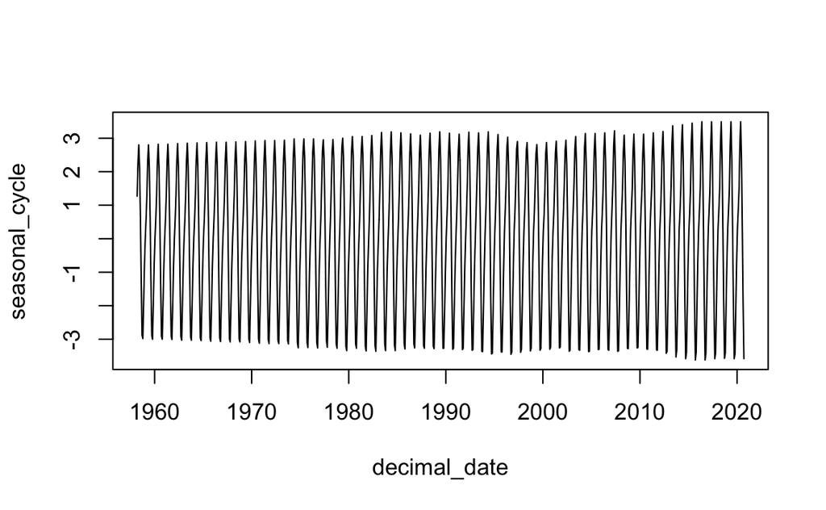

```r
co2$seasonal_cycle = co2$monthly_average - co2$deseasonalized #Calculate detrended co2 fluctuation
head(co2)
##   year month decimal_date monthly_average deseasonalized n_days st_dev_days
## 1 1958     3     1958.203          315.70         314.43     -1       -9.99
## 2 1958     4     1958.288          317.45         315.16     -1       -9.99
## 3 1958     5     1958.370          317.51         314.71     -1       -9.99
## 4 1958     6     1958.455          317.24         315.14     -1       -9.99
## 5 1958     7     1958.537          315.86         315.18     -1       -9.99
## 6 1958     8     1958.622          314.93         316.18     -1       -9.99
##   monthly_mean_uncertainty seasonal_cycle
## 1                    -0.99           1.27
## 2                    -0.99           2.29
## 3                    -0.99           2.80
## 4                    -0.99           2.10
## 5                    -0.99           0.68
## 6                    -0.99          -1.25
plot(seasonal_cycle ~ decimal_date, type="l", data=co2)
```

We can subset the data to look at the most recent 5 years. This will allow us to see the monthly cycle better. Here’s a quick refresher on subsetting:

```r
# 2 ways to get the third row of the first column:
co2[1,3]
## [1] 1958.203
co2$year[3]
## [1] 1958

# 2 ways to get the whole second column (commented out bc it's a lot to print)
# co2[,2]
# co2$month

# 2 ways to get the first 6 rows of every column
co2[c(1:6),]
##   year month decimal_date monthly_average deseasonalized n_days st_dev_days
## 1 1958     3     1958.203          315.70         314.43     -1       -9.99
## 2 1958     4     1958.288          317.45         315.16     -1       -9.99
## 3 1958     5     1958.370          317.51         314.71     -1       -9.99
## 4 1958     6     1958.455          317.24         315.14     -1       -9.99
## 5 1958     7     1958.537          315.86         315.18     -1       -9.99
## 6 1958     8     1958.622          314.93         316.18     -1       -9.99
##   monthly_mean_uncertainty seasonal_cycle
## 1                    -0.99           1.27
## 2                    -0.99           2.29
## 3                    -0.99           2.80
## 4                    -0.99           2.10
## 5                    -0.99           0.68
## 6                    -0.99          -1.25
head(co2)
##   year month decimal_date monthly_average deseasonalized n_days st_dev_days
## 1 1958     3     1958.203          315.70         314.43     -1       -9.99
## 2 1958     4     1958.288          317.45         315.16     -1       -9.99
## 3 1958     5     1958.370          317.51         314.71     -1       -9.99
## 4 1958     6     1958.455          317.24         315.14     -1       -9.99
## 5 1958     7     1958.537          315.86         315.18     -1       -9.99
## 6 1958     8     1958.622          314.93         316.18     -1       -9.99
##   monthly_mean_uncertainty seasonal_cycle
## 1                    -0.99           1.27
## 2                    -0.99           2.29
## 3                    -0.99           2.80
## 4                    -0.99           2.10
## 5                    -0.99           0.68
## 6                    -0.99          -1.25
```

To subset our data, we can write a boolean expression to create a vector of logical variables, which we have already done a bit in previous lessons. We can also use the `which()` function to return just the indices of the elements in the vector that meet some logical criteria. Subsetting is an important and common activity in R (and data science in general) so it’s good to be exposed to multiple ways that you may see programmers accomplish the same task. There are still other ways to subset, including using the `subset()` function (which is used less commonly) or using `filter()` in the `dplyr` package (which is very common and we’ll cover it later).

So to grab the last 5 years of data (plus a few months), we only want values of `co2$decimal_date` greater than 2015. We can use a conditional statement `>` to signal values *greater than* 2015:

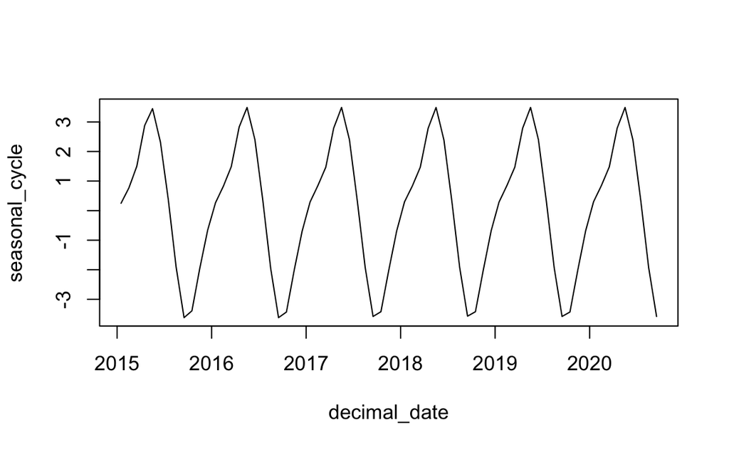

```r
# Showing 2 ways to subset
summary(co2$decimal_date > 2015) # vector of TRUES and FALSES
##    Mode   FALSE    TRUE
## logical     682      69
summary(which(co2$decimal_date > 2015)) # vector of indices that meet condition (see ?which for bells and whistles)
##    Min. 1st Qu.  Median    Mean 3rd Qu.    Max.
##     683     700     717     717     734     751

# Either method can be used to subset the data
co2_2016to2020 = co2[co2$decimal_date > 2015,]

plot(seasonal_cycle ~ decimal_date, type="l", data=co2_2016to2020)
```

It’s a little hard to figure out which month is which on this plot. Let’s make a table that shows the average CO2 anomaly for each month over the time series. We can calculate the monthly anomaly for January by subsetting only data where `month==1` and then taking the mean of our `seasonal_cycle` variable.

```r
# 2 ways to grab seasonal_cycle data only from the month of January
# jan_anomalies = co2[which(co2$month==1),'seasonal_cycle']
jan_anomalies = co2$seasonal_cycle[which(co2$month==1)]

# Calculate the mean of the january anomalies over the time period
mean(jan_anomalies)
## [1] 0.09580645
```

Now let’s calculate the average monthly anomaly for all 12 months. To do this, let’s make a new data.frame that will hold our results. It should have two columns: one for month and one for the average anomaly for that month. Then we can calculate the average anomaly for each month, just like we did above, and insert in into the right spot in our data.frame:

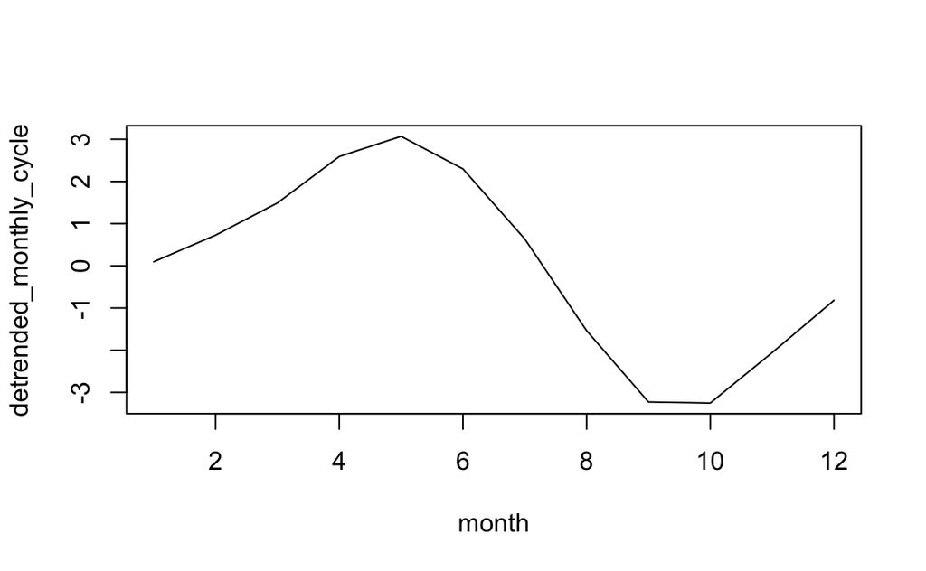

```r
head(co2)
##   year month decimal_date monthly_average deseasonalized n_days st_dev_days
## 1 1958     3     1958.203          315.70         314.43     -1       -9.99
## 2 1958     4     1958.288          317.45         315.16     -1       -9.99
## 3 1958     5     1958.370          317.51         314.71     -1       -9.99
## 4 1958     6     1958.455          317.24         315.14     -1       -9.99
## 5 1958     7     1958.537          315.86         315.18     -1       -9.99
## 6 1958     8     1958.622          314.93         316.18     -1       -9.99
##   monthly_mean_uncertainty seasonal_cycle
## 1                    -0.99           1.27
## 2                    -0.99           2.29
## 3                    -0.99           2.80
## 4                    -0.99           2.10
## 5                    -0.99           0.68
## 6                    -0.99          -1.25
co2_monthly_cycle = data.frame(month=c(1:12), detrended_monthly_cycle=NA) #Note how it automatically recycles NA to fill the column
head(co2_monthly_cycle)
##   month detrended_monthly_cycle
## 1     1                      NA
## 2     2                      NA
## 3     3                      NA
## 4     4                      NA
## 5     5                      NA
## 6     6                      NA

co2_monthly_cycle$detrended_monthly_cycle[1] = mean(co2[which(co2$month==1),'seasonal_cycle'])
co2_monthly_cycle$detrended_monthly_cycle[2] = mean(co2[which(co2$month==2),'seasonal_cycle'])
co2_monthly_cycle$detrended_monthly_cycle[3] = mean(co2[which(co2$month==3),'seasonal_cycle'])
co2_monthly_cycle$detrended_monthly_cycle[4] = mean(co2[which(co2$month==4),'seasonal_cycle'])
co2_monthly_cycle$detrended_monthly_cycle[5] = mean(co2[which(co2$month==5),'seasonal_cycle'])
co2_monthly_cycle$detrended_monthly_cycle[6] = mean(co2[which(co2$month==6),'seasonal_cycle'])
co2_monthly_cycle$detrended_monthly_cycle[7] = mean(co2[which(co2$month==7),'seasonal_cycle'])
co2_monthly_cycle$detrended_monthly_cycle[8] = mean(co2[which(co2$month==8),'seasonal_cycle'])
co2_monthly_cycle$detrended_monthly_cycle[9] = mean(co2[which(co2$month==9),'seasonal_cycle'])
co2_monthly_cycle$detrended_monthly_cycle[10] = mean(co2[which(co2$month==10),'seasonal_cycle'])
co2_monthly_cycle$detrended_monthly_cycle[11] = mean(co2[which(co2$month==11),'seasonal_cycle'])
co2_monthly_cycle$detrended_monthly_cycle[12] = mean(co2[which(co2$month==12),'seasonal_cycle'])

# Examine and plot detrended monthly cycle
co2_monthly_cycle
##    month detrended_monthly_cycle
## 1      1              0.09580645
## 2      2              0.72693548
## 3      3              1.49031746
## 4      4              2.59000000
## 5      5              3.06904762
## 6      6              2.29777778
## 7      7              0.63571429
## 8      8             -1.53698413
## 9      9             -3.22761905
## 10    10             -3.25322581
## 11    11             -2.05709677
## 12    12             -0.81758065
plot(detrended_monthly_cycle ~ month, type="l", data=co2_monthly_cycle)
```

Wow. wasn’t that horrible? I don’t know about you, but repeating that line of code 12 times and making just a small change on each line was demoralizing for me. Also, this style of coding is prone to errors. Luckily you are going to learn tons of tricks to optimize your programming to avoid repetition, make your code more efficient and more readable. All in good time.

So it looks like peak CO2 levels occur in May, and the lowest CO2 levels occur in October. There seems to be a consistent range of about 6 ppm CO2 in a given year. This is related to global autotrophic respiration rates.

The seasonal cycle reveals that CO2 concentrations decrease during periods corresponding to the spring and summer months in the Northern Hemisphere. This decline is explained by the rapid leafing of vegetation during the early spring and subsequent plant growth in the summer, when the influence of photosynthesis is greatest. (Photosynthesis removes CO2 from the air and converts it, along with water and other minerals, into oxygen and organic compounds that can be used for plant growth.) When spring arrives in the Northern Hemisphere, the portion of the planet that contains most of the land area and vegetation cover, the increased rate of photosynthesis outpaces the production of CO2, and a decrease in carbon dioxide concentrations can be observed in the curve. As photosynthetic rates slow and plant decay increases in the Northern Hemisphere during the autumn and winter months, atmospheric CO2 concentrations rise.

### Exercise 4.1

As a result of climate change, there have been many phenological changes in the physical and biological environment. That means that there is a shift in the timing of seasonal phenomena and activities. One of the most obvious examples of this is that as many parts of the world warm, the spring growing season for plants is starting a bit earlier each spring. Plot the seasonal cycle of co2 for 1959 (the first full year of data) and 2019 (the last full year of data) on the same figure. What do you notice? Is this a robust analysis to determine if there has been a phenological shift in global carbon uptake / respiration?